Name: Syeduzzaman Khan

Startup Name: Feluda

# 1. Objectives:

Crimes are the part of human history. Prehistoric age to modern age, human are disobeyed law and committed crimes against human, societies, and country. In this project, we are going to analyze the crime dataset which are collected over 40 years in different USA cities.

The purpose of this project is to analyze the crime dataset and help law enforcement agencies to provide different aspects of their cities.

To achieve our goals, we have to carefully analyze the dataset considering different perspectives. In the beginning of the project, we will get to familiar with dataset and look into different columns. Then, we will pick the relevant columns that will lead us to reach our goals. The obtained results will be visualized using plot.

# 2. Data Exploration:

Read dataset

```python
# import Library
import pandas as pd
import matplotlib.pyplot as plt
%matplotlib inline
```

```python
# read csv file
df = read_csv("report.csv")
```

[output not shown]

```python
df.head(5)
```

|  | report_year | agency_code | agency_jurisdiction | population | violent_crimes | homicides | rapes | assaults | robberies | months_reported | crimes_percapita | homicides_percapita | rapes_percapita | assaults_percapita | robberies_percapita |
| --- | --- | --- | --- | --- | --- | --- | --- | --- | --- | --- | --- | --- | --- | --- | --- |
| 1743 | 2000 | VA02901 | Fairfax County, VA | 933641.0 | 154.0 | 2.0 | 30.0 | 15.0 | 107.0 | 12.0 | 16.49 | 0.21 | 3.21 | 1.61 | 11.46 |
| 1812 | 2001 | VA02901 | Fairfax County, VA | 948050.0 | 249.0 | 2.0 | 32.0 | 42.0 | 173.0 | 12.0 | 26.26 | 0.21 | 3.38 | 4.43 | 18.25 |
| 1881 | 2002 | VA02901 | Fairfax County, VA | 961999.0 | 480.0 | 8.0 | 41.0 | 130.0 | 301.0 | 12.0 | 49.90 | 0.83 | 4.26 | 13.51 | 31.29 |
| 2088 | 2005 | VA02901 | Fairfax County, VA | 980586.0 | 575.0 | 14.0 | 57.0 | 206.0 | 298.0 | 12.0 | 58.64 | 1.43 | 5.81 | 21.01 | 30.39 |
| 2019 | 2004 | VA02901 | Fairfax County, VA | 973406.0 | 594.0 | 2.0 | 32.0 | 206.0 | 354.0 | 12.0 | 61.02 | 0.21 | 3.29 | 21.16 | 36.37 |

### Dataframe Type, Dataframe Row & Column:

```python
type(df)
```

```
pandas.core.frame.DataFrame
```

```python
print("Row: ",df.shape[0])
```

```
Row:  2829
```

```python
print("Column: ",df.shape[1])
```

```
Column:  15
```

The dataset has total 2829 rows and 15 columns. The data are collected from 1975 to 2015.

### Percentiles of the numerical values:

```python
#1 Population information over 40 years in multiple cities
population=df.population # create pandas series from dataframe
population.describe() # print different aspects of data
```

```
count    2.760000e+03
mean     7.956981e+05
std      1.012451e+06
min      1.007630e+05
25%      3.779310e+05
50%      5.366145e+05
75%      8.168558e+05
max      8.550861e+06
Name: population, dtype: float64
```

```python
# 2 Violent crimes over 40 years in multiple cities
violent_crimes=df.violent_crimes  # create pandas series from dataframe
violent_crimes.describe()# print different aspects of data
```

```
count    2.794000e+03
mean     2.963255e+04
std      1.728630e+05
min      1.540000e+02
25%      3.014750e+03
50%      5.135500e+03
75%      9.058500e+03
max      1.932274e+06
Name: violent_crimes, dtype: float64
```

```python
#3  Homicides over 40 years in multiple cities
homicides=df.homicides # create pandas series from dataframe
homicides.describe() # print different aspects of data
```

```
count     2795.000000
mean       398.385331
std       2281.276402
min          1.000000
25%         32.000000
50%         64.000000
75%        131.000000
max      24703.000000
Name: homicides, dtype: float64
```

```python
#4  Crimes percapita over 40 years in multiple cities
crimes_percapita=df.crimes_percapita # create pandas series from dataframe
crimes_percapita.describe() # print different aspects of data
```

```
count    2794.000000
mean     1093.049810
std       676.884678
min        16.490000
25%       625.082500
50%       949.680000
75%      1409.507500
max      4352.830000
Name: crimes_percapita, dtype: float64
```

The above paragraphs show the different aspects of multiple columns of data set. The information includes mean, max, min, and percentiles of the specific columns.

# 3. One column selection

```python
# selection of  a column from dataset

crimes_percapita = df['crimes_percapita'].copy() # crime per capita has selected , .copy function does not affect the original dataset columns
print("Index:   Values:") # print title
crimes_percapita.nlargest(10) # print largest 10 values
```

```
Index:   Values:
```

```
1069    4352.83
1138    4190.84
1037    4085.36
1106    4050.51
1244    4041.18
1422    3985.29
968     3951.40
1276    3892.96
1077    3881.97
1302    3874.92
Name: crimes_percapita, dtype: float64
```

# 4. Sort

```python
# create new dataset: 5 columns
df1=df[df['agency_jurisdiction']=='Fresno, CA']# dataset based on Fresno, CA county
df2 = pd.DataFrame(df1, columns = ['report_year','violent_crimes','homicides','rapes','robberies'])
print("Fresno, CA county Dataset: ")
df2.head(5)  # print top 5 rows of new dataset
```

```
Fresno, CA county Dataset:
```

|  | report_year | violent_crimes | homicides | rapes | robberies |
| --- | --- | --- | --- | --- | --- |
| 2711 | 2014 | 2382.0 | 47.0 | 53.0 | 781.0 |
| 2642 | 2013 | 2552.0 | 40.0 | 53.0 | 903.0 |
| 2573 | 2012 | 2748.0 | 51.0 | 54.0 | 1015.0 |
| 2780 | 2015 | 2871.0 | 39.0 | 167.0 | 1012.0 |
| 2504 | 2011 | 2915.0 | 35.0 | 51.0 | 1020.0 |

```python
# sorting columns : violent_crimes
violent_crimes1=df2['violent_crimes'].copy()
ascending = violent_crimes1.sort_values(ascending=False)
print("Top 5 Violent Crimes number:")
print(ascending[:5])


# sorting columns : homicides
homicides=df2['homicides'].copy()
ascending1 = homicides.sort_values(ascending=False)
print("\nTop 5 Homicides number:")
print(ascending1[:5])
```

```
Top 5 Violent Crimes number:
1331    6199.0
1400    5659.0
1262    5511.0
1469    5461.0
1193    5363.0
Name: violent_crimes, dtype: float64

Top 5 Homicides number:
1262    87.0
1331    84.0
1193    81.0
1400    71.0
1469    69.0
Name: homicides, dtype: float64
```

### Results Explaination:

The extracted new dataset will give a summary of original dataset. Here, all the required columns are gathered together for achieving our main research goals. By analyzing it, we can get the Fresno, CA county's crimes information.

# 5. Series:

```python
# violent_crimes data aspects
a=df2.violent_crimes
print("Mean: ",a.mean())
print("Max: ",a.max())
print("Min: ",a.min())
```

```
Mean:  3358.8048780487807
Max:  6199.0
Min:  1141.0
```

```python
# homicides data aspects
b=df2.homicides
print("Mean: ",b.mean())
print("Max: ",b.max())
print("Min: ",b.min())
```

```
Mean:  46.4390243902439
Max:  87.0
Min:  24.0
```

```python
# rapes data aspects
c=df2.rapes
print("Mean: ",c.mean())
print("Max: ",c.max())
print("Min: ",c.min())
```

```
Mean:  154.34146341463415
Max:  282.0
Min:  51.0
```

```python
# rapes data aspects
d=df2.robberies
print("Mean: ",d.mean())
print("Max: ",d.max())
print("Min: ",d.min())
```

```
Mean:  1362.3902439024391
Max:  3094.0
Min:  567.0
```

The minimum, maximum, and average values of 4 four different data series will help to get an idea of those crimes situation in the recent years at Fresno county.

# 6. Plot:

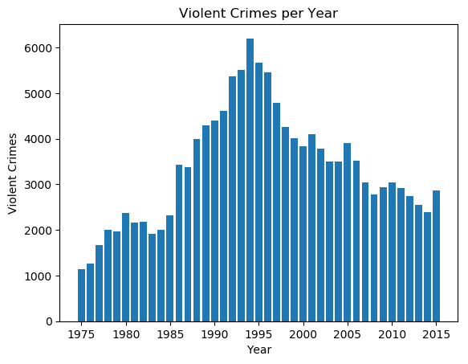

```python
# plot violent crimes yearly using a bar chart


import matplotlib.pyplot as plt; plt.rcdefaults()
import numpy as np
import matplotlib.pyplot as plt

df3 = pd.DataFrame(df1, columns = ['report_year','violent_crimes','homicides','rapes','robberies'])

y_pos=df3.report_year
performance=df3.violent_crimes
plt.bar(y_pos, performance, align='center', alpha=1)
plt.ylabel('Violent Crimes')
plt.xlabel('Year')

plt.title('Violent Crimes per Year')
plt.show()
```

The bar chart depicts the yearly violent crimes between 1975 to 2015. In 1975, the number of violent crimes was minimum. As days going on, the violent crimes have increased and it reached maximum in 1994. After 1995, there was a trend to decrease the violent crimes.

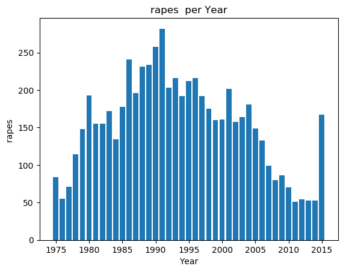

```python
y_pos=df3.report_year
performance=df3.rapes
plt.bar(y_pos, performance, align='center', alpha=1)
plt.ylabel('rapes ')
plt.xlabel('Year')

plt.title('rapes  per Year')
plt.show()
```

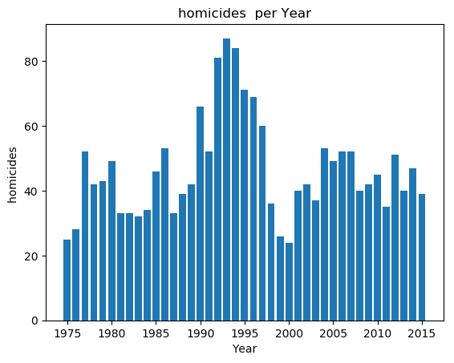

```python
y_pos=df3.report_year
performance=df3.homicides
plt.bar(y_pos, performance, align='center', alpha=1)
plt.ylabel('homicides ')
plt.xlabel('Year')

plt.title('homicides  per Year')
plt.show()
```

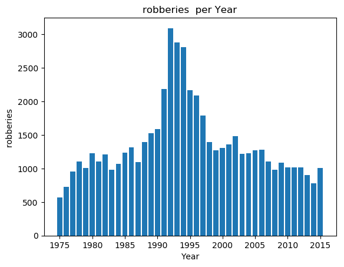

```python
y_pos=df3.report_year
performance=df3.robberies
plt.bar(y_pos, performance, align='center', alpha=1)
plt.ylabel('robberies ')
plt.xlabel('Year')

plt.title('robberies  per Year')
plt.show()
```

# 7. Summery:

The analysis of dataset represents a good insight of crime history of USA. The dataset is reliable ( by size, rows: 2829, columns: 15). Therefore, the chance to get almost optimal solution for small projects is moderate.

Fresno, CA county is our company's point of interest county. We want to work with the county's law enforcement authority to help the crime control and prevention of the county. The average violent crimes is 3358.8. From the figure, we can observe the violent crimes rate has fallen under the 40 years average number. That is the good sign for the Fresno county.

The average values of homicides, rapes and robberies are as follows: 46.43, 154.34, and 1362.39. The homicides plot shows the fluctuating of number of homicides in the recent years. The rapes crime had been decreased dramatically after the year of 2000 which indicated the success of law enforcement authority. But the rates had increased in 2015 which would be concerned for them. Robberies had been reduced after the year of 1995 and remained under control till 2015.

# 8. Recommendations: